# Код с комментариями по второму заданию

Пахомова, Пантелеева, Кулик, группа 411

### Описание задания

Целью второго задания было проведение разведывательного анализа данных для того, чтобы определить, с каким из поставщиков стали следует заключить договор, основываясь на имеющихся данных по производству оружия и количеству единиц сломанного оружия за каждый месяц каждым из кузнецов двух анализируемых компаний.

### Выполнение задания

Код состоит из трёх основных блоков.

- Сначала идёт перенастройка директории, считывание исходных данных из файла `production-data.csv` и инициализация переменных.

```r
data <- read.csv(file = "D:/Rita/ppp-2017/ppp-2017/tasks/task2/production-data.csv", header = TRUE)
sum_defect <- 0
sum_produced <- 0
table1 <- c()
table2 <- c()
count <- 0
```

- Во втором блоке идёт обработка данных для дальнейшего их использования в анализе.

Обработка производится следующим образом:

Для обеих компаний в разных циклах считаются вектора длиной 6 `table1` и `table2`, содержащие общее количество целых мечей, произведённых компанией, на данный момент времени: из значения количества произведённых мечей в партии `sum_produced` вычитается сумма количества сломанных мечей от рассматриваемой партии `sum_defect` на данный момент времени, все значения берутся суммарно по всем кузнецам компании.

Т.е. если в первый месяц было произведено Х мечей всеми кузнецами компании, и за 6 месяцев сломалось Y мечей от количества произведенного X, то первым элементом вектора будет значение (X - Y), и т.д.

```r
for (j in 1:6) {
  for (i in 1:50) {
    for (k in 1:(8-j)) {
      sum_defect <- sum_defect + data[k+27*(i-1)+count,5]
    }
    sum_produced <- sum_produced + data[27*(i-1)+1+count,4]
    sum_produced <- sum_produced - sum_defect
    sum_defect <- 0
  }
  table1 <- append(table1, sum_produced)
  sum_produced <- 0
  count <- count + (8-j)
}
count <- 0
for (j in 1:6) {
  for (i in 51:100) {
    for (k in 1:(8-j)) {
      sum_defect <- sum_defect + data[k+27*(i-1)+count,5]
    }
    sum_produced <- sum_produced + data[27*(i-1)+1+count,4]
    sum_produced <- sum_produced - sum_defect
    sum_defect <- 0
  }
  table2 <- append(table2, sum_produced)
  sum_produced <- 0
  count <- count + (8-j)
}
```

- В последнем блоке данные выводятся на диаграмме размаха (“Ящик с усами”) для дальнейшего анализа эффективности производства каждой из компаний. Для этого используем функцию `boxplot()`.

По оси абсцисс стоят рассматриваемые компании, по оси ординат значения векторов `table1` и `table2`.

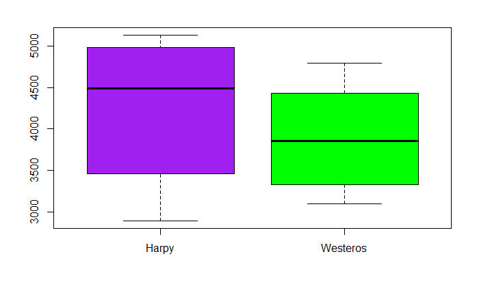

```r
Companies <- c("Harpy", "Harpy", "Harpy", "Harpy", "Harpy", "Harpy", "Westeros", "Westeros", "Westeros", "Westeros", "Westeros", "Westeros")
Month <- c(table1, table2)
boxplot(Month ~ Companies, col=c("purple", "green"))
```

Далее, прогнозируем значения. Для этого найдём количество сломавшихся мечей относительно произведённых в долях единицы и отследим зависимость значений от каких-либо внешних факторов. Кривые значений ищем отдельно для каждой компании. В цикле находим максимальноеи минимальное значение доли единицы количества сломавшихся мечей.

```r
produced <- c(data$produced[data$produced > 0])
produced
```

[output not shown]

```r
monthDefects <-c (0,0,0,0,0,0)
monthDefectsMax <- monthDefects
monthDefectsMin <- c(10,10,10,10,10,10)
for (i in 1:50) {
  monthIndex = 0;
  for (j in 1:6) {
    monthLength = (8-j)
    monthProduced = produced[(i-1)*6 + j]
    for (k in 2:monthLength) {
      relDefects = data$defects[(i-1)*27 + monthIndex + k] / monthProduced
      monthDefects[k-1] = monthDefects[k-1] + relDefects
      if (relDefects > monthDefectsMax[k-1])
        monthDefectsMax[k-1] = relDefects
      if (relDefects < monthDefectsMin[k-1])
        monthDefectsMin[k-1] = relDefects
    }
    monthIndex = monthIndex + monthLength
  }
}
for (i in 1:6)
  monthDefects[i] = monthDefects[i]/(50*(7-i))
monthDefectsMin
```

```
[1] 0.01818182 0.00000000 0.00000000 0.10091743 0.08737864 0.04950495
```

```r
monthDefectsMax
```

```
[1] 0.03921569 0.05504587 0.04950495 0.18181818 0.16981132 0.14545455
```

```r
monthDefects
```

```
[1] 0.02477320 0.02557435 0.02471795 0.14485436 0.12288842 0.10219930
```

```r
monthDefects.co <- monthDefects
monthDefects <-c (0,0,0,0,0,0)
monthDefectsMax <- monthDefects
monthDefectsMin <- c(10,10,10,10,10,10)
for (i in 51:100) {
  monthIndex = 0
  for (j in 1:6) {
    monthLength = (8-j)
    monthProduced = produced[(i-1)*6 + j]
    for (k in 2:monthLength) {
      relDefects = data$defects[(i-1)*27 + monthIndex + k] / monthProduced
      monthDefects[k-1] = monthDefects[k-1] + relDefects
      if (relDefects > monthDefectsMax[k-1])
        monthDefectsMax[k-1] = relDefects
      if (relDefects < monthDefectsMin[k-1])
        monthDefectsMin[k-1] = relDefects
    }
    monthDataIndex = monthIndex + monthLength
  }
}
```

```r
for (i in 1:6)
  monthDefects[i] = monthDefects[i]/(50*(7-i));
monthDefectsMin
```

```
[1]  0.063636364  0.045454545  0.027272727  0.027272727 -0.009433962  0.000000000
```

```r
monthDefectsMax
```

```
[1] 0.1089109 0.1274510 0.1470588 0.1176471 0.1386139 0.1067961
```

```r
monthDefects
```

```
[1] 0.08522493 0.07698510 0.07630774 0.06324514 0.05940794 0.05327707
```

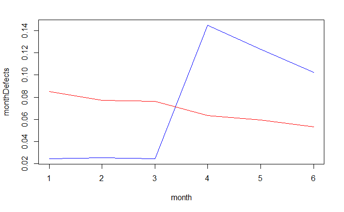

```r
monthDefects.inc<-monthDefects
month <- c(1:6)
plot(month, monthDefects.co, col="blue", type="l", ylab="monthDefects")
lines(monthDefects.inc, col="red")
```

### Список участников

- Пахомова Маргарита, 411 группа - *Написание кода*
- Пантелеева Анастасия, 411 группа - *Написание Rnotebook и презентации*
- Кулик Артём, 411 группа - *Написание кода*
- Чабан Олег, 412 группа - *Написание презентации*